# 2003 Intermediate Quantitative Methods

Assignment 4

Tong Jin

10/22/2019

### Part 1

In this part, you will analyze dataset `toy_example3.csv` that we used in class.

```r
# Import the dataset toy_example3.csv as `toy3`
toy3 <- read.csv("toy_example3.csv", header = TRUE)

# Create a dummy variable `male` and mark rows which Gender equals to 'M' as
# 1, and 'F' as 0.
toy3$male <- as.numeric(toy3$Gender == "M")
```

### Question 1 of 13

First fit a regression model using height and gender (Male) (i.e., Female is the reference group) as predictors for weight, assuming an additive relationship; then fit the regression again assuming an interaction relationship between height and gender. Match the assumptions/interpretations with the appropriate model.

**[Hint: make sure you code variable gender appropriately to model the gender effect as instructed.]**

1. The effect of height on weight is the same for male and for female.
2. The gender difference in weight is the same for any height.
3. The effect of height on weight is more pronounced among males than among females, i.e. greater positive slope among males.
4. The gender difference in weight is wider among taller people.

##### Answer:

**Here is the code for creating addition and interactive regression models with summaries.**

```r
lm_add <- lm(Weight ~ Height + Gender, data = toy3)
summary(lm_add)
```

```
##
## Call:
## lm(formula = Weight ~ Height + Gender, data = toy3)
##
## Residuals:
##     Min      1Q  Median      3Q     Max
## -70.368 -13.384  -0.107  14.263  62.384
##
## Coefficients:
##             Estimate Std. Error t value Pr(>|t|)
## (Intercept)  33.1872    15.2535   2.176     0.03 *
## Height        1.4185     0.2301   6.164 1.46e-09 ***
## GenderM       9.7232     2.0477   4.748 2.69e-06 ***
## ---
## Signif. codes:  0 '***' 0.001 '**' 0.01 '*' 0.05 '.' 0.1 ' ' 1
##
## Residual standard error: 20.24 on 497 degrees of freedom
## Multiple R-squared:  0.1844, Adjusted R-squared:  0.1811
## F-statistic: 56.17 on 2 and 497 DF,  p-value: < 2.2e-16
```

```r
lm_inter <- lm(Weight ~ Height * Gender, data = toy3)
summary(lm_inter)
```

```
##
## Call:
## lm(formula = Weight ~ Height * Gender, data = toy3)
##
## Residuals:
##    Min     1Q Median     3Q    Max
## -68.90 -13.00  -0.50  13.52  61.24
##
## Coefficients:
##                Estimate Std. Error t value Pr(>|t|)
## (Intercept)     68.9328    20.9023   3.298  0.00104 **
## Height           0.8774     0.3158   2.778  0.00568 **
## GenderM        -68.0695    31.3503  -2.171  0.03038 *
## Height:GenderM   1.1400     0.4584   2.487  0.01322 *
## ---
## Signif. codes:  0 '***' 0.001 '**' 0.01 '*' 0.05 '.' 0.1 ' ' 1
##
## Residual standard error: 20.14 on 496 degrees of freedom
## Multiple R-squared:  0.1944, Adjusted R-squared:  0.1895
## F-statistic:  39.9 on 3 and 496 DF,  p-value: < 2.2e-16
```

**Assumption 1:** *The effect of height on weight is the same for male and for female.*

This is suitable for an **Addition Model** because the slopes of Female’s and Male’s relationship of $Height$ and $Weight$ will be **the same**. This also means that the curves of Female and Male are **parallel**.

We can create a plot to examine whether an addtion regression model is suitable for this assumption.

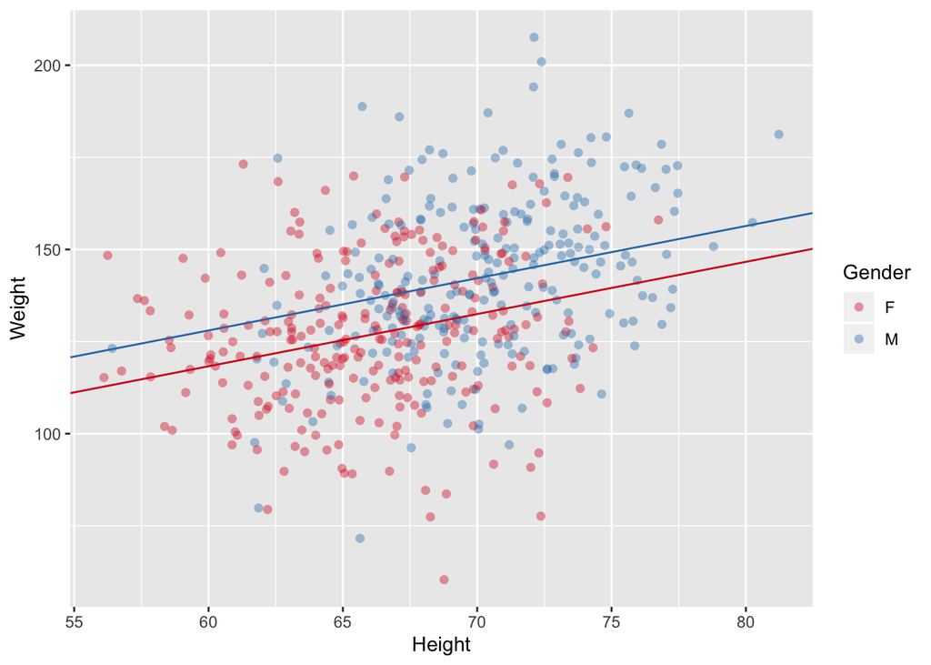

```r
# Summarize coefficients from the addition regression model: Intercept for
# Female
lm_add_int_F <- summary(lm_add)$coef[1]

# Intercept for Male
lm_add_int_M <- summary(lm_add)$coef[1] + summary(lm_add)$coef[3]

# Slope
lm_add_slope <- summary(lm_add)$coef[2]

# Create plot to show the relationship of addition between Female and Male.
ggplot(toy3, aes(x = Height, y = Weight, col = Gender)) + geom_point(alpha = 0.4,
    shape = 16, size = 2) + scale_color_manual(values = c("#d7191c", "#2c7bb6")) +
    geom_abline(aes(intercept = lm_add_int_F, slope = lm_add_slope), col = "#d7191c") +
    geom_abline(aes(intercept = lm_add_int_M, slope = lm_add_slope), col = "#2c7bb6")
```

**Assumption 2:** *The gender difference in weight is the same for any height.*

This is suitable for an **Addition Model** because the slope of Female’s and Male’s relationships of $Weight$ and $Height$ will be **the same**. This also means that the curves of Female and Male are **parallel**.

We can create a plot to examine whether an addtion regression model is suitable for this assumption.

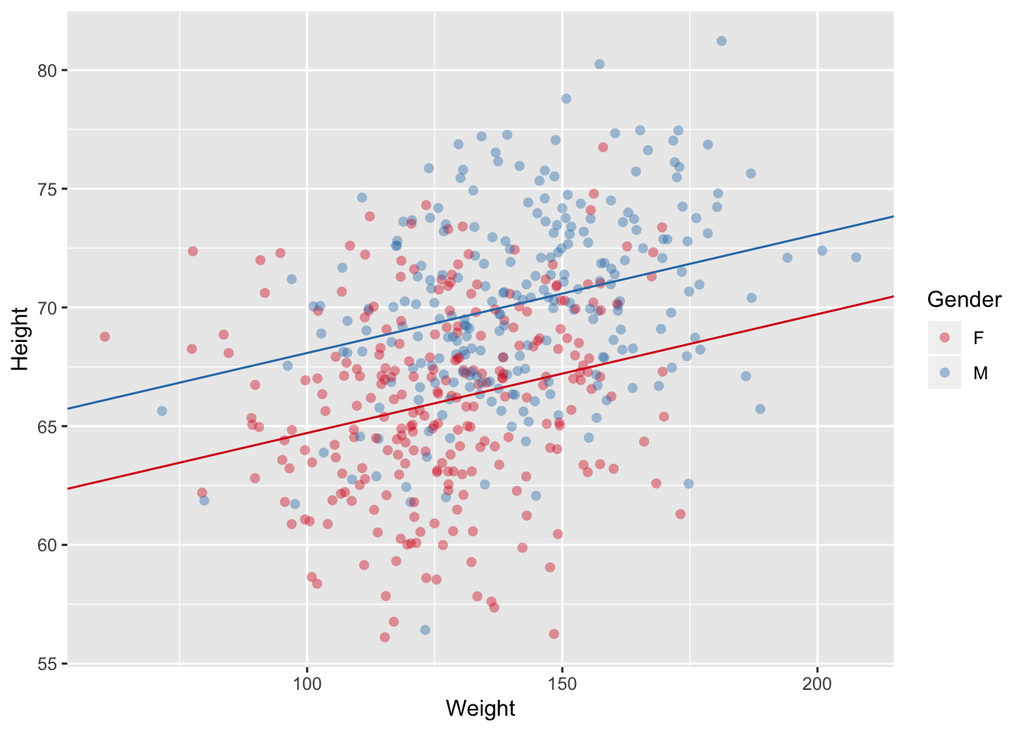

```r
# Create a new regression model and summarize coefficients.
lm_add2 <- lm(Height ~ Weight + Gender, data = toy3)

# Intercept for Female
lm_add2_int_F <- summary(lm_add2)$coef[1]

# Intercept for Male
lm_add2_int_M <- summary(lm_add2)$coef[1] + summary(lm_add2)$coef[3]

# Slope
lm_add2_slope <- summary(lm_add2)$coef[2]

# Create plot to show the relationship of addition between Female and Male.
ggplot(toy3, aes(x = Weight, y = Height, col = Gender)) + geom_point(alpha = 0.4,
    shape = 16, size = 2) + scale_color_manual(values = c("#d7191c", "#2c7bb6")) +
    geom_abline(aes(intercept = lm_add2_int_F, slope = lm_add2_slope), col = "#d7191c") +
    geom_abline(aes(intercept = lm_add2_int_M, slope = lm_add2_slope), col = "#2c7bb6")
```

**Assumption 3:** *The effect of height on weight is more pronounced among males than among females, i.e. greater positive slope among males.*

This is suitable for an **Interactive Model** because the slope of Male’s relationship of $Height$ and $Weight$ will be **greater** than the slope of Female’s. This also means that the curves of Female and Male are **non-parallel**.

We can create a plot to examine whether an interactive regression model is suitable for this assumption.

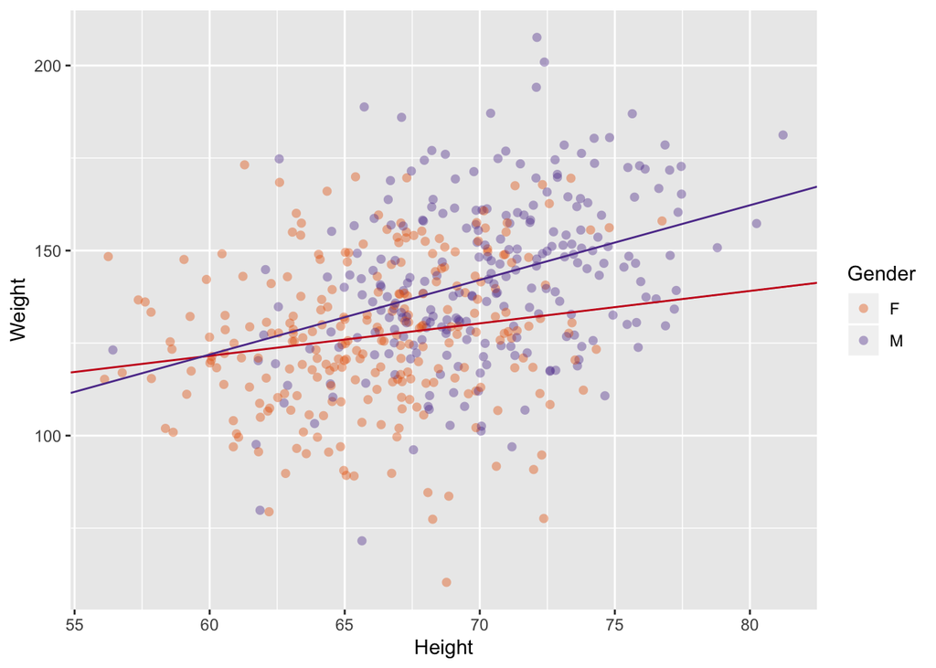

```r
# Summarize coefficients from the interactive regression model: Intercept
# for Female
lm_inter_int_F <- summary(lm_inter)$coef[1]

# Intercept for Male
lm_inter_int_M <- summary(lm_inter)$coef[1] + summary(lm_inter)$coef[3]

# Slope for Female
lm_inter_slope_F <- summary(lm_inter)$coef[2]

# Slope for Male
lm_inter_slope_M <- summary(lm_inter)$coef[2] + summary(lm_inter)$coef[4]

# Create plot to show the relationship of addition between Female and Male.
ggplot(toy3, aes(x = Height, y = Weight, col = Gender)) + geom_point(alpha = 0.4,
    shape = 16, size = 2) + scale_color_manual(values = c("#e66101", "#5e3c99")) +
    geom_abline(aes(intercept = lm_inter_int_F, slope = lm_inter_slope_F), col = "#ca0020") +
    geom_abline(aes(intercept = lm_inter_int_M, slope = lm_inter_slope_M), col = "#5e3c99")
```

**Assumption 4:** *The gender difference in weight is wider among taller people.*

This is suitable for an **Interactive Model** because the slope of Male’s relationship of $Weight$ and $Height$ will be **greater** than the slope of Female’s. This also means that the curves of Female and Male are **non-parallel**.

We can create a plot to examine whether an interactive regression model is suitable for this assumption.

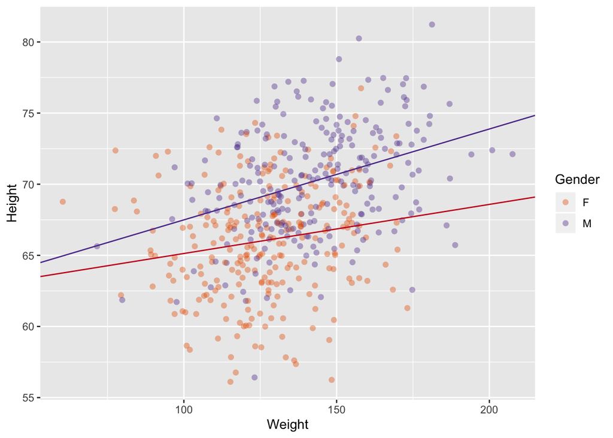

```r
# Create a new regression model and summarize coefficients.
lm_inter2 <- lm(Height ~ Weight * Gender, data = toy3)

# Intercept for Female
lm_inter2_int_F <- summary(lm_inter2)$coef[1]

# Intercept for Male
lm_inter2_int_M <- summary(lm_inter2)$coef[1] + summary(lm_inter2)$coef[3]

# Slope for Female
lm_inter2_slope_F <- summary(lm_inter2)$coef[2]

# Slope for Male
lm_inter2_slope_M <- summary(lm_inter2)$coef[2] + summary(lm_inter2)$coef[4]

# Create plot to show the relationship of addition between Female and Male.
ggplot(toy3, aes(x = Weight, y = Height, col = Gender)) + geom_point(alpha = 0.4,
    shape = 16, size = 2) + scale_color_manual(values = c("#e66101", "#5e3c99")) +
    geom_abline(aes(intercept = lm_inter2_int_F, slope = lm_inter2_slope_F),
        col = "#ca0020") + geom_abline(aes(intercept = lm_inter2_int_M, slope = lm_inter2_slope_M),
    col = "#5e3c99")
```

### Question 2 of 13

In order to answer the following questions, you will need to create a new variable with “centralized” height. The mean height in this data set is 67.6inches, generate a new variable called “height0” using the code below (assumes you’ve named the dataset “dat”). Round to two decimal places and do not use scientific notation: $dat$height0 <- dat$Height - mean(dat$Height)$

##### Answer:

```r
mHeight <- mean(toy3$Height)
toy3$height0 <- toy3$Height - mHeight
paste(round(mean(toy3$height0), digits = 2), ".00")
```

```
## [1] "0 .00"
```

### Question 3 of 13

Run a new regression of weight (DV) regressed on an interaction between height0 and gender (IVs), namely: $weight=height0+gender+height0*gender$. Compare this model to the one with the original height variable interacted with gender ($weight=height+gender+height*gender$). Which of the following coefficients are different in these two models (check all that apply)?

##### Answer:

**Intercept**

**Coefficient on gender (may come up as GenderM in code output)**

```r
summary(lm_inter)
```

```
##
## Call:
## lm(formula = Weight ~ Height * Gender, data = toy3)
##
## Residuals:
##    Min     1Q Median     3Q    Max
## -68.90 -13.00  -0.50  13.52  61.24
##
## Coefficients:
##                Estimate Std. Error t value Pr(>|t|)
## (Intercept)     68.9328    20.9023   3.298  0.00104 **
## Height           0.8774     0.3158   2.778  0.00568 **
## GenderM        -68.0695    31.3503  -2.171  0.03038 *
## Height:GenderM   1.1400     0.4584   2.487  0.01322 *
## ---
## Signif. codes:  0 '***' 0.001 '**' 0.01 '*' 0.05 '.' 0.1 ' ' 1
##
## Residual standard error: 20.14 on 496 degrees of freedom
## Multiple R-squared:  0.1944, Adjusted R-squared:  0.1895
## F-statistic:  39.9 on 3 and 496 DF,  p-value: < 2.2e-16
```

```r
lm3 <- lm(Weight ~ height0 * Gender, data = toy3)
summary(lm3)
```

```
##
## Call:
## lm(formula = Weight ~ height0 * Gender, data = toy3)
##
## Residuals:
##    Min     1Q Median     3Q    Max
## -68.90 -13.00  -0.50  13.52  61.24
##
## Coefficients:
##                 Estimate Std. Error t value Pr(>|t|)
## (Intercept)     128.6650     1.4085  91.350  < 2e-16 ***
## height0           0.8774     0.3158   2.778  0.00568 **
## GenderM           9.5371     2.0384   4.679 3.73e-06 ***
## height0:GenderM   1.1400     0.4584   2.487  0.01322 *
## ---
## Signif. codes:  0 '***' 0.001 '**' 0.01 '*' 0.05 '.' 0.1 ' ' 1
##
## Residual standard error: 20.14 on 496 degrees of freedom
## Multiple R-squared:  0.1944, Adjusted R-squared:  0.1895
## F-statistic:  39.9 on 3 and 496 DF,  p-value: < 2.2e-16
```

### Question 4 of 13

For the regression of weight as a function of height0 interacted with gender: Which of the following is a correct interpretation of the intercept?

##### Answer:

**Expected average weight of females who are average height.**

### Question 5 of 13

For the regression of weight as a function of height0 interacted with gender: Which of the following is a correct interpretation of the slope coefficient on height0?

##### Answer:

**Average difference in weight for females whose heights differ by one inch.**

### Question 6 of 13

For the regression of weight as a function of height0 interacted with gender: Which of the following is a correct interpretation of the coefficient on gender (probably represented as GenderM in your code output)?

##### Answer:

**Difference in average weight of males and females who are average height.**

### Question 7 of 13

Based on the model with height0 interacted with gender: what is the expected difference in weights for two groups of males whose heights differ by one inch? (round to 2 decimals)

##### Answer:

```r
round(summary(lm3)$coef[2] + summary(lm3)$coef[4], digits = 2)
```

```
## [1] 2.02
```

### Question 8 of 13

When replacing height with height0 in these models, the R squares of the models are not affected.

##### Answer:

**True**

### Question 9 of 13

Run two separate regression models, weight on centered height, one for male and one for female (in other words, create two separate datasets, one with just the females and the other with just the males, then run the regression model Weight~height0 for each dataset separately). This approach is also called to stratify the sample based on gender. Examine the results of these two gender specific models, and compare the results with the model you ran in previous questions ($Weight~height0+gender+height0*gender$). Choose all the answers that are correct. R hint: `lm(weight~height0, data=data[data$Gender=="Male",]) lm(weight~height0, data=data[data$Gender=="Female",])` stata hint: `reg weight height0 if Gender=="Male" reg weight height0 if Gender=="Female"`.

##### Answer:

```r
toy3_m <- subset(toy3, toy3$Gender == "M")
toy3_f <- subset(toy3, toy3$Gender == "F")

lm_m <- lm(Weight ~ height0, data = toy3_m)
lm_f <- lm(Weight ~ height0, data = toy3_f)

summary(lm3)
```

```
##
## Call:
## lm(formula = Weight ~ height0 * Gender, data = toy3)
##
## Residuals:
##    Min     1Q Median     3Q    Max
## -68.90 -13.00  -0.50  13.52  61.24
##
## Coefficients:
##                 Estimate Std. Error t value Pr(>|t|)
## (Intercept)     128.6650     1.4085  91.350  < 2e-16 ***
## height0           0.8774     0.3158   2.778  0.00568 **
## GenderM           9.5371     2.0384   4.679 3.73e-06 ***
## height0:GenderM   1.1400     0.4584   2.487  0.01322 *
## ---
## Signif. codes:  0 '***' 0.001 '**' 0.01 '*' 0.05 '.' 0.1 ' ' 1
##
## Residual standard error: 20.14 on 496 degrees of freedom
## Multiple R-squared:  0.1944, Adjusted R-squared:  0.1895
## F-statistic:  39.9 on 3 and 496 DF,  p-value: < 2.2e-16
```

```r
summary(lm_m)
```

```
##
## Call:
## lm(formula = Weight ~ height0, data = toy3_m)
##
## Residuals:
##     Min      1Q  Median      3Q     Max
## -61.696 -12.881  -0.516  13.248  61.245
##
## Coefficients:
##             Estimate Std. Error t value Pr(>|t|)
## (Intercept) 138.2021     1.4977  92.274  < 2e-16 ***
## height0       2.0174     0.3377   5.974 8.28e-09 ***
## ---
## Signif. codes:  0 '***' 0.001 '**' 0.01 '*' 0.05 '.' 0.1 ' ' 1
##
## Residual standard error: 20.47 on 241 degrees of freedom
## Multiple R-squared:  0.129,  Adjusted R-squared:  0.1254
## F-statistic: 35.68 on 1 and 241 DF,  p-value: 8.28e-09
```

```r
summary(lm_f)
```

```
##
## Call:
## lm(formula = Weight ~ height0, data = toy3_f)
##
## Residuals:
##     Min      1Q  Median      3Q     Max
## -68.902 -12.996  -0.485  13.684  50.448
##
## Coefficients:
##             Estimate Std. Error t value Pr(>|t|)
## (Intercept) 128.6650     1.3863  92.812  < 2e-16 ***
## height0       0.8774     0.3109   2.822  0.00514 **
## ---
## Signif. codes:  0 '***' 0.001 '**' 0.01 '*' 0.05 '.' 0.1 ' ' 1
##
## Residual standard error: 19.82 on 255 degrees of freedom
## Multiple R-squared:  0.03029,    Adjusted R-squared:  0.02649
## F-statistic: 7.966 on 1 and 255 DF,  p-value: 0.005142
```

```r
anova(lm3)
```

|  | Df | Sum Sq | Mean Sq | F value | Pr(>F) |
| --- | --- | --- | --- | --- | --- |
| height0 | 1 | 36780.334 | 36780.3342 | 90.721362 | 7.295274e-20 |
| Gender | 1 | 9236.773 | 9236.7730 | 22.783171 | 2.389798e-06 |
| height0:Gender | 1 | 2506.918 | 2506.9178 | 6.183495 | 1.322259e-02 |
| Residuals | 496 | 201088.754 | 405.4209 | NA | NA |

```r
anova(lm_m)
```

|  | Df | Sum Sq | Mean Sq | F value | Pr(>F) |
| --- | --- | --- | --- | --- | --- |
| height0 | 1 | 14945.1 | 14945.0950 | 35.68316 | 8.280203e-09 |
| Residuals | 241 | 100937.5 | 418.8277 | NA | NA |

```r
anova(lm_f)
```

|  | Df | Sum Sq | Mean Sq | F value | Pr(>F) |
| --- | --- | --- | --- | --- | --- |
| height0 | 1 | 3128.712 | 3128.7117 | 7.966163 | 0.00514163 |
| Residuals | 255 | 100151.287 | 392.7501 | NA | NA |

**The following arguments are true:**

B. The intercept and slope of the female regression line between weight and height(centered) are the same between two approaches.

F. The residual degrees of freedom of the interaction model equals to the residual degrees of freedom of male model plus the female model.

G. One difference between the two approaches is that in the interaction model we only estimate one model variance, while in the gender stratified approach, we estimate two model variances.

H. One difference between the two approaches is that we now have smaller number of observations in each of the two gender specific models than in the one combined model.

### Part 2

#### In the following questions, you will reanalyze the class example of birthweight and race using `toy_ex3.csv`.

### Question 10 of 13

Fit a regression of birth weight on race using Hispanic as reference group, and match the regression coefficients below.

Hint: You can either generate dummy variables to represent the race variable (code below) or re-level the Race variable so that the reference group is Hispanic: `dat$White <- as.numeric(dat$Race=="W`“)dat$Black <- as.numeric(dat$Race==”B“)dat$Hispanic <- as.numeric(dat$Race==”H“)dat$Other <- as.numeric(dat$Race==”O")`

##### Answer:

```r
dat <- read.csv("toy_ex3.csv", header = TRUE)
dat$White <- as.numeric(dat$Race == "W")
dat$Black <- as.numeric(dat$Race == "B")
dat$Hispanic <- as.numeric(dat$Race == "H")
dat$Other <- as.numeric(dat$Race == "O")

lm4 <- lm(BirthWeight ~ White + Black + Other, data = dat)
summary(lm4)
```

```
##
## Call:
## lm(formula = BirthWeight ~ White + Black + Other, data = dat)
##
## Residuals:
##      Min       1Q   Median       3Q      Max
## -1476.20  -308.72    -4.06   294.11  1457.78
##
## Coefficients:
##             Estimate Std. Error t value Pr(>|t|)
## (Intercept)  3277.04      28.80 113.795  < 2e-16 ***
## White         120.29      39.08   3.078  0.00214 **
## Black         -42.32      42.32  -1.000  0.31752
## Other         154.79      39.17   3.952 8.26e-05 ***
## ---
## Signif. codes:  0 '***' 0.001 '**' 0.01 '*' 0.05 '.' 0.1 ' ' 1
##
## Residual standard error: 459.9 on 1074 degrees of freedom
## Multiple R-squared:  0.02967,    Adjusted R-squared:  0.02696
## F-statistic: 10.95 on 3 and 1074 DF,  p-value: 4.391e-07
```

**Black: -42.3** **White: 120.3** **Other: 154.8**

### Question 11 of 13

Based on the regression you just ran: on average, Black babies are expected to weigh _______ grams less than Hispanic babies.

##### Answer:

```r
round(abs(summary(lm4)$coef[3]), digits = 2)
```

```
## [1] 42.32
```

### Question 12 of 13

Based on the same regression result, at level 5%, there is a statistically significant difference in birth weight between Black and Hispanic babies.

##### Answer:

**FALSE**

### Question 13 of 13

On average, the birth weight of a White baby is ______ grams higher than that of a Black baby (round to one decimal place).

##### Answer:

```r
round(120.29 + 42.32, digits = 1)
```

```
## [1] 162.6
```